# Analyzing Individual BGG Users

Phil Henrickson

2022-01-02

# **Cappa’s** BoardGameGeek Collection

This notebook contains a set of analyses for the selected user’s boardgamegeek collection. The bulk of the analysis is focused on building a user-specific predictive model to predict the games that Cappa is likely to own. This enables to ask questions like, based on the games the user currently owns, what games are a good fit for their collection? What upcoming games are they likely to purchase?

This analysis is based on data from BoardGameGeek that was last updated on **2021-12-20.**

# 1 Collection Overview

We can look at a basic description of the number of games that the user owns, has rated, has previously owned, etc.

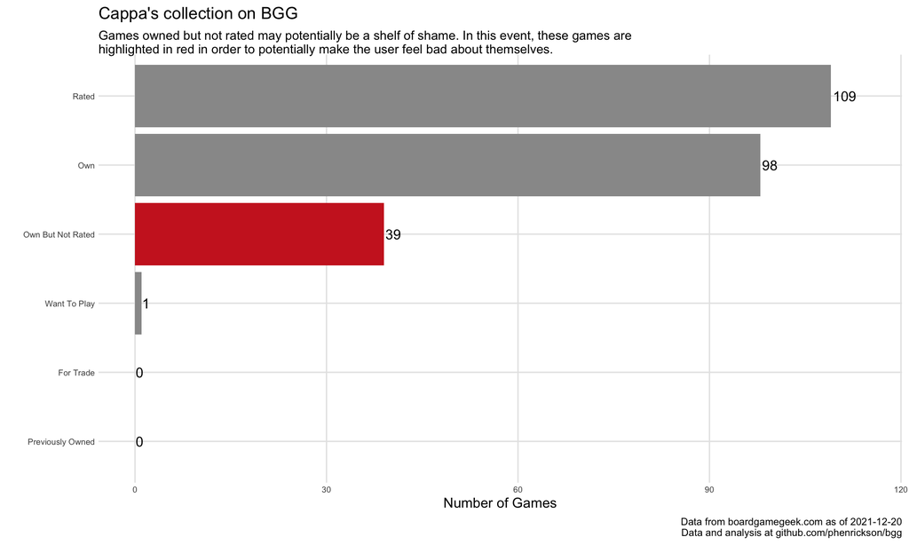

What years has the user owned/rated games from? While we can’t see when a user added or removed a game from their collection, we can look at their collection by the years in which their games were published.

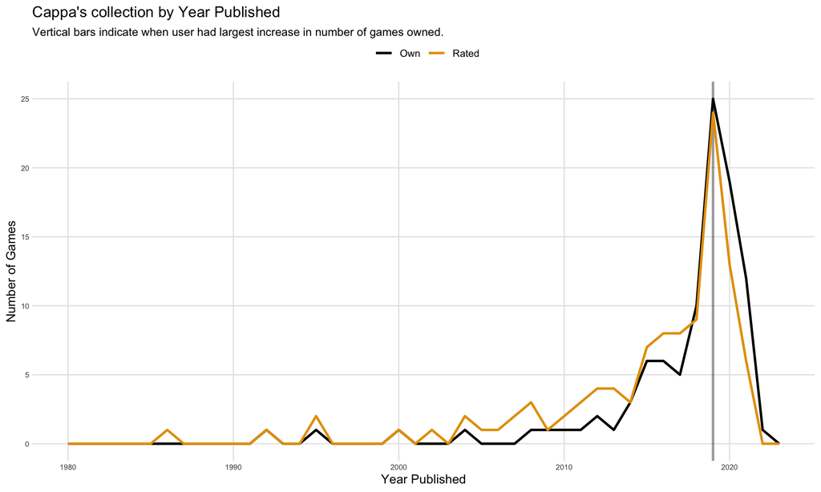

## 1.1 What types of games does Cappa own?

We can look at the most frequent types of categories, mechanics, designers, and artists that appear in a user’s collection.

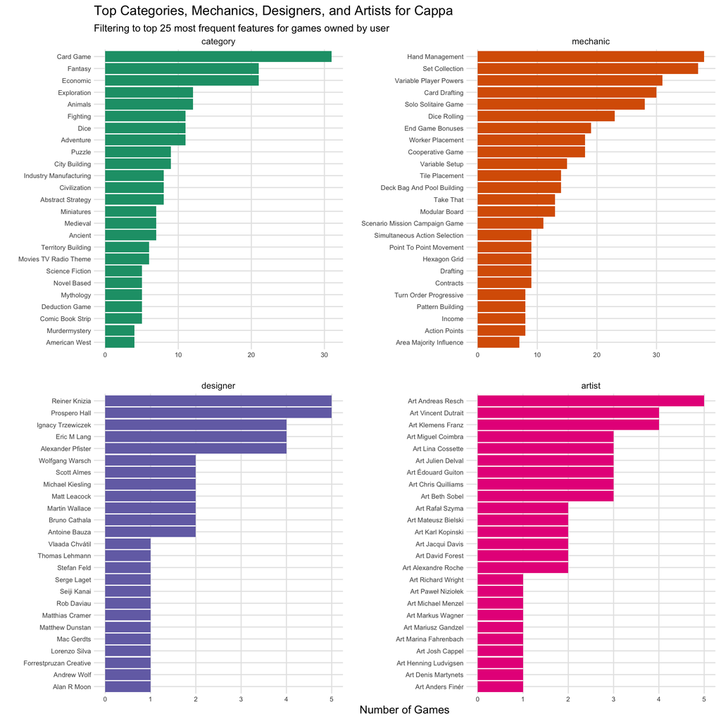

# 2 Modeling **Cappa’s** Collection

| username | dataset | period | games_owned | games_rated | games_played |
| --- | --- | --- | --- | --- | --- |
| Cappa | training | published before 2020 | 65 | 90 | 110 |
| Cappa | test | published 2020 or later | 32 | 19 | 37 |

There are two main (binary) outcomes we will be modeling for the user.

The first, **own** refers to whether the user currently lists a game as owned in their collection. The second, **played** refers to whether the user currently owns, has rated, or previously owned a game. This means the latter will generally have a larger list of games, but may still be a useful category to examine for people who play lots of games without necessarily owning them.

We will train predictive models to learn the probability that the user will own or play individual games based on their features.

## 2.1 Coefficients for Cappa

We can examine coefficients from the trained modes, which are penalized logistic regressions fit to our two main outcomes. Positive values indicate that a feature increases a user’s probabilility of owning/rating a game, while negative values indicate a feature decreases the probability.

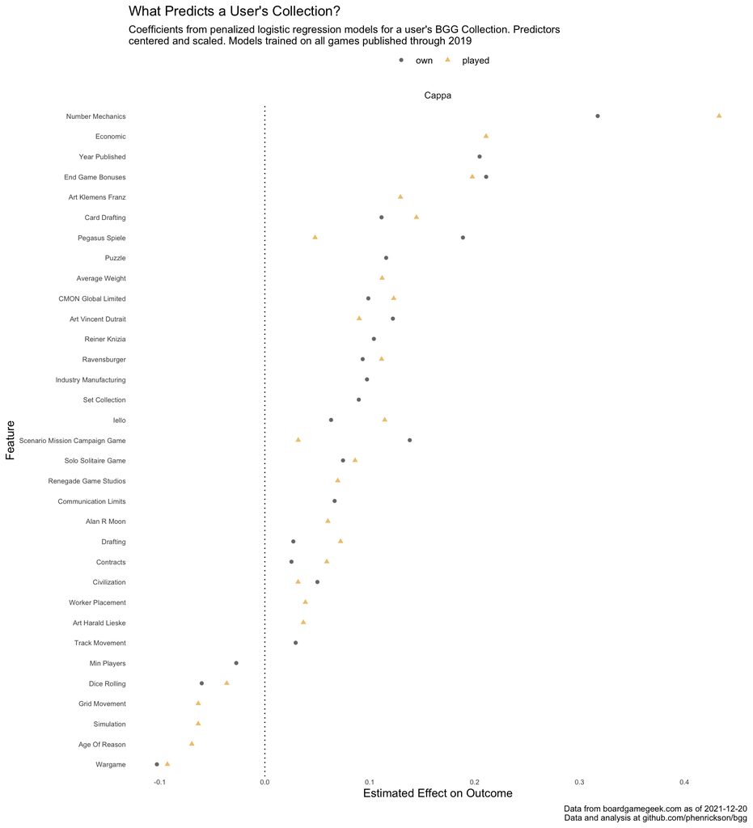

## 2.2 Visualizing Predictors for Cappa’s Collection

Why did the model identify these features? We can make density plots of the important features for predicting whether the user owned a game. Blue indicates the density for games owned by the user, while grey indicates the density for games not owned by the user.

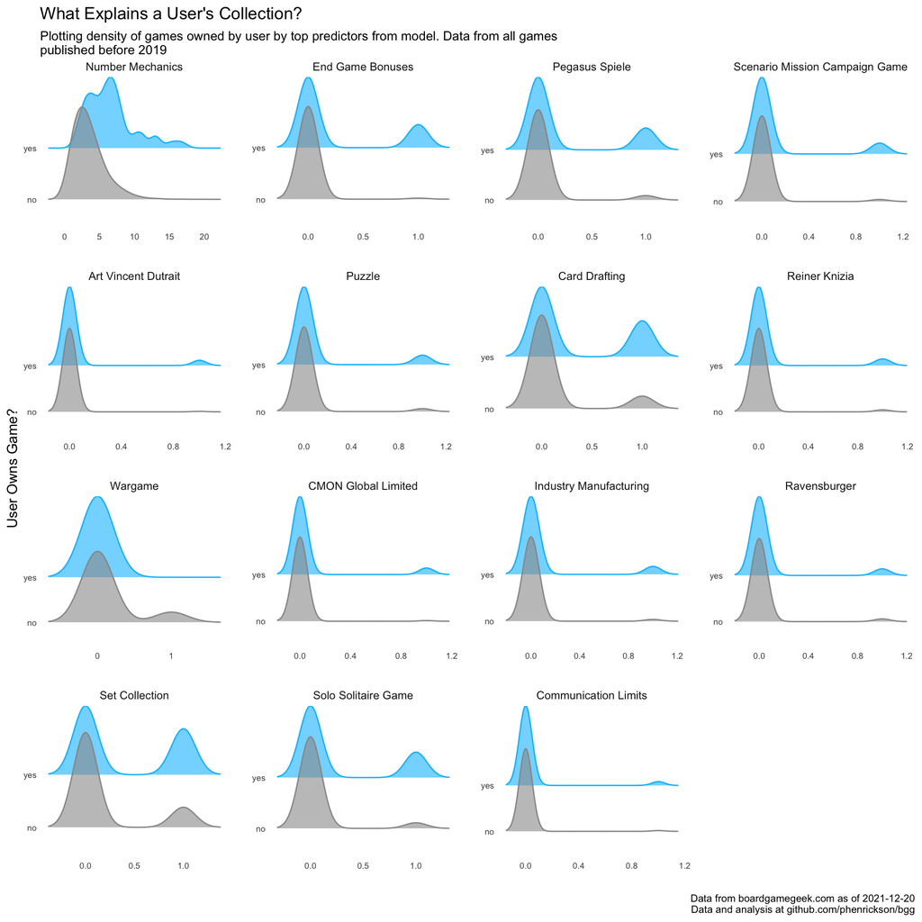

Binary predictors can be difficult to see with this visualization, so we can also directly examine the percentage of games in a user’s collection with a predictor vs the percentage of all games with that predictor.

| username | Feature | % of Games with Feature In_Collection | % of Games with Feature All_Games | Ratio |
| --- | --- | --- | --- | --- |
| Cappa | End Game Bonuses | 24.6% | 1.1% | 22.4 |
| Cappa | CMON Global Limited | 7.7% | 0.8% | 9.9 |
| Cappa | Track Movement | 6.2% | 0.6% | 9.9 |
| Cappa | Contracts | 9.2% | 1.0% | 9.5 |
| Cappa | Drafting | 9.2% | 1.0% | 9.3 |
| Cappa | Variable Setup | 13.8% | 1.8% | 7.7 |
| Cappa | Scenario Mission Campaign Game | 12.3% | 2.3% | 5.4 |
| Cappa | Pegasus Spiele | 23.1% | 4.6% | 5.0 |
| Cappa | Communication Limits | 4.6% | 1.0% | 4.7 |
| Cappa | Industry Manufacturing | 9.2% | 2.0% | 4.6 |
| Cappa | Solo Solitaire Game | 26.2% | 5.8% | 4.5 |
| Cappa | Civilization | 9.2% | 2.6% | 3.5 |
| Cappa | Puzzle | 10.8% | 3.3% | 3.3 |
| Cappa | Iello | 9.2% | 3.1% | 3.0 |
| Cappa | Card Drafting | 33.8% | 11.8% | 2.9 |
| Cappa | Deck Bag And Pool Building | 13.8% | 4.8% | 2.9 |
| Cappa | Ravensburger | 7.7% | 3.2% | 2.4 |
| Cappa | Set Collection | 40.0% | 17.5% | 2.3 |
| Cappa | Take That | 15.4% | 6.6% | 2.3 |
| Cappa | Animals | 13.8% | 6.8% | 2.0 |
| Cappa | Hand Management | 44.6% | 26.6% | 1.7 |
| Cappa | Dice Rolling | 18.5% | 29.0% | 0.6 |
| Cappa | Wargame | 0.0% | 12.5% | 0.0 |
| Cappa | Simulation | 0.0% | 8.0% | 0.0 |
| Cappa | Age Of Reason | 0.0% | 0.8% | 0.0 |

# 3 Assess Model’s Performance on Training Set

Before predicting games in upcoming years, we can examine how well the model did and what games it liked in the training set. In this case, we used resampling techniques (cross validation) to ensure that the model had not seen a game before making its predictions.

## 3.1 Separation Plot

An easy way to examine the performance of classification model is to view a separation plot. We plot the predicted probabilities from the model for every game (from resampling) from lowest to highest. We then overlay a blue line for any game that the user does own. A good classifier is one that is able to *separate* the blue (games owned by the user) from the white (games not owned by the user), with most of the blue occurring at the highest probabilities (right side of the chart).

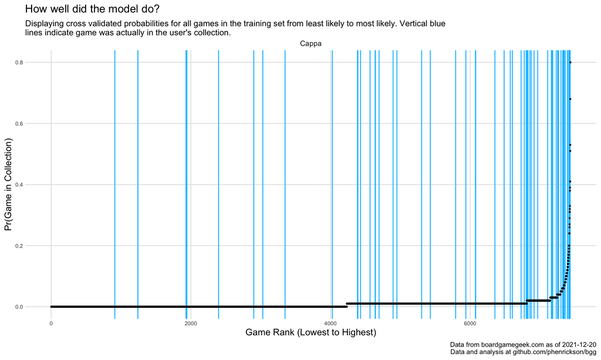

## 3.2 Top Games for **Cappa** from Training Set

We can display this information in table form, displaying the 100 games with the highest probability of ownership, adding a blue line when the user does own the game.

| username | yearpublished | game_id | name | pred_played | pred_own | actual_played | actual_own |
| --- | --- | --- | --- | --- | --- | --- | --- |
| Cappa | 2019 | 283863 | The Magnificent | 0.92 | 0.80 | 0 | 0 |
| Cappa | 2018 | 205896 | Rising Sun | 0.91 | 0.68 | 0 | 0 |
| Cappa | 2019 | 270971 | Era: Medieval Age | 0.36 | 0.53 | 0 | 0 |
| Cappa | 2018 | 244711 | Newton | 0.93 | 0.51 | 0 | 0 |
| Cappa | 2019 | 276025 | Maracaibo | 0.77 | 0.41 | 1 | 1 |
| Cappa | 2019 | 260710 | Amul | 0.48 | 0.41 | 0 | 0 |
| Cappa | 2012 | 121921 | Robinson Crusoe: Adventures on the Cursed Island | 0.13 | 0.39 | 1 | 1 |
| Cappa | 2018 | 199792 | Everdell | 0.54 | 0.38 | 1 | 1 |
| Cappa | 2019 | 269603 | Minecraft: Builders & Biomes | 0.24 | 0.33 | 0 | 0 |
| Cappa | 2019 | 257066 | Sierra West | 0.49 | 0.32 | 1 | 1 |
| Cappa | 2018 | 247763 | Underwater Cities | 0.20 | 0.31 | 0 | 0 |
| Cappa | 2011 | 70919 | Takenoko | 0.33 | 0.31 | 0 | 0 |
| Cappa | 2019 | 266507 | Clank!: Legacy – Acquisitions Incorporated | 0.39 | 0.29 | 1 | 1 |
| Cappa | 2019 | 265736 | Tiny Towns | 0.55 | 0.27 | 1 | 1 |
| Cappa | 2019 | 271324 | It's a Wonderful World | 0.46 | 0.26 | 1 | 1 |
| Cappa | 2013 | 52461 | Legacy: The Testament of Duke de Crecy | 0.56 | 0.24 | 0 | 0 |
| Cappa | 2017 | 174430 | Gloomhaven | 0.22 | 0.24 | 0 | 0 |
| Cappa | 2014 | 149097 | Spurs: A Tale in the Old West | 0.12 | 0.24 | 0 | 0 |
| Cappa | 2017 | 217861 | Paper Tales | 0.20 | 0.24 | 0 | 0 |
| Cappa | 2012 | 119391 | Il Vecchio | 0.32 | 0.20 | 0 | 0 |
| Cappa | 2018 | 258444 | Gingerbread House | 0.07 | 0.20 | 0 | 0 |
| Cappa | 2019 | 251247 | Barrage | 0.64 | 0.20 | 0 | 0 |
| Cappa | 2019 | 287954 | Azul: Summer Pavilion | 0.07 | 0.19 | 1 | 1 |
| Cappa | 2017 | 217372 | The Quest for El Dorado | 0.05 | 0.18 | 1 | 1 |
| Cappa | 2005 | 17133 | Railways of the World | 0.30 | 0.18 | 0 | 0 |
| Cappa | 2016 | 185589 | Islebound | 0.29 | 0.17 | 0 | 0 |
| Cappa | 2012 | 123096 | Space Cadets | 0.03 | 0.17 | 0 | 0 |
| Cappa | 2015 | 163967 | Tiny Epic Galaxies | 0.30 | 0.17 | 0 | 0 |
| Cappa | 2015 | 175878 | 504 | 0.46 | 0.16 | 0 | 0 |
| Cappa | 2010 | 62219 | Dominant Species | 0.40 | 0.16 | 0 | 0 |

[output cut: 70 more lines]

We can also more formally assess how well the model did in resampling by looking at the area under the receiver operating characteristic. A perfect model would receive a score of 1, while a model that cannot predict the outcome will default to a score of 0.5. The extent to which something is a *good* score depends on the setting, but generally anything in the .8 to .9 range is very good while the .7 to .8 range is perfectly acceptable.

| username | outcome_type | .metric | .estimator | .estimate |
| --- | --- | --- | --- | --- |
| Cappa | own | roc_auc | binary | 0.824 |
| Cappa | played | roc_auc | binary | 0.862 |

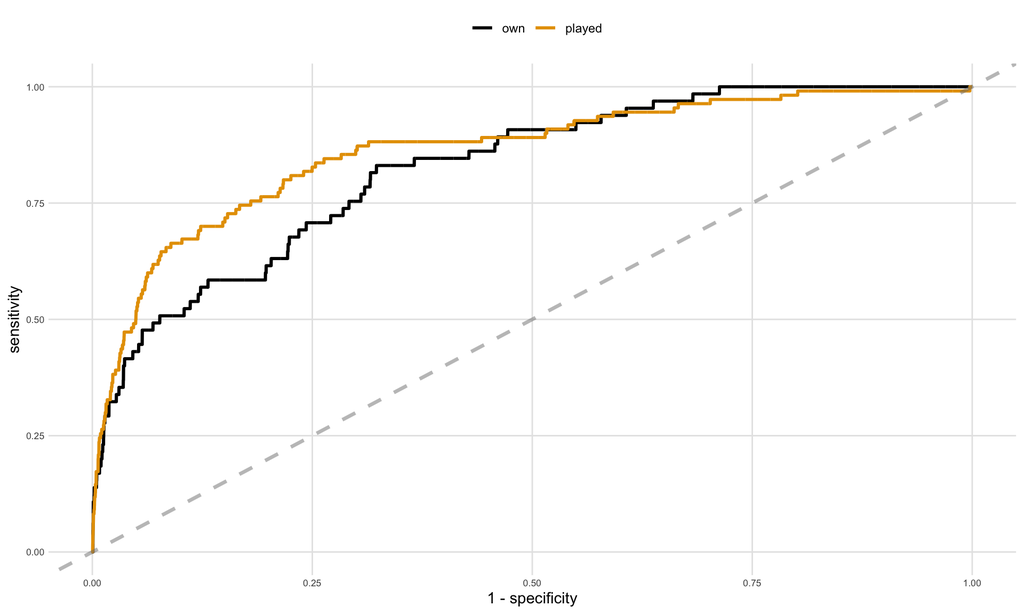

Another way to think about the model performance is to view its lift, or its ability to detect the positive outcomes over that of a null model. High lift indicates the model can much more quickly find all of the positive outcomes (in this case, games owned or played by the user), while a model with no lift is no better than random guessing.

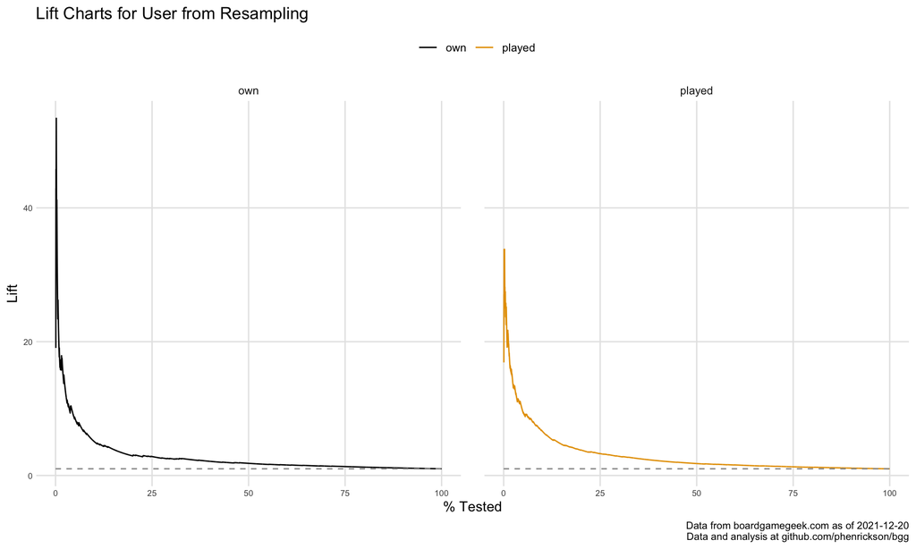

## 3.3 Most and Least Likely Games

What games does the model think Cappa is **most likely to own** that are **not** in their collection?

| username | yearpublished | game_id | name | pred_own | actual_own |
| --- | --- | --- | --- | --- | --- |
| Cappa | 2019 | 283863 | The Magnificent | 0.80 | 0 |
| Cappa | 2018 | 205896 | Rising Sun | 0.68 | 0 |
| Cappa | 2019 | 270971 | Era: Medieval Age | 0.53 | 0 |
| Cappa | 2018 | 244711 | Newton | 0.51 | 0 |
| Cappa | 2019 | 260710 | Amul | 0.41 | 0 |

What games does the model think Cappa is **least likely to own** that **are** in their collection?

| username | yearpublished | game_id | name | pred_own | actual_own |
| --- | --- | --- | --- | --- | --- |
| Cappa | 2014 | 164928 | Orléans | 0 | 1 |
| Cappa | 2019 | 287589 | Red Outpost | 0 | 1 |
| Cappa | 2019 | 292032 | Funkoverse Strategy Game: Harry Potter 100 | 0 | 1 |
| Cappa | 2016 | 194655 | Santorini | 0 | 1 |
| Cappa | 2018 | 244992 | The Mind | 0 | 1 |

## 3.4 Top Games by Year

Top 25 games most likely to be owned by the user in each year, highlighting in blue the games that the user has owned/played.

| rank | 2011 | 2012 | 2013 | 2014 | 2015 | 2016 | 2017 | 2018 | 2019 |
| --- | --- | --- | --- | --- | --- | --- | --- | --- | --- |
| 1 | Takenoko | Robinson Crusoe: Adventures on the Cursed Island | Legacy: The Testament of Duke de Crecy | Spurs: A Tale in the Old West | Tiny Epic Galaxies | Islebound | Gloomhaven | Rising Sun | The Magnificent |
| 2 | Mage Knight Board Game | Il Vecchio | Lewis & Clark: The Expedition | Castles of Mad King Ludwig | 504 | The Manhattan Project: Energy Empire | Paper Tales | Newton | Era: Medieval Age |
| 3 | Village | Space Cadets | Pathfinder Adventure Card Game: Rise of the Runelords – Base Set | Alchemists | Grand Austria Hotel | Scythe | The Quest for El Dorado | Everdell | Maracaibo |
| 4 | Mansions of Madness | Keyflower | Sushi Go! | Camel Up | Blood Rage | 13 Days: The Cuban Missile Crisis | Mythic Battles: Pantheon | Underwater Cities | Amul |
| 5 | A Few Acres of Snow | Tokaido | Russian Railroads | Three Kingdoms Redux | Discoveries: The Journals of Lewis & Clark | Terraforming Mars | Calimala | Gingerbread House | Minecraft: Builders & Biomes |
| 6 | Feudalia | Targi | Brew Crafters | Arcadia Quest | The Bloody Inn | Sushi Go Party! | First Martians: Adventures on the Red Planet | Azul: Stained Glass of Sintra | Sierra West |
| 7 | Santiago de Cuba | Tzolk'in: The Mayan Calendar | Patchistory | Five Tribes | Raptor | Inis | Gaia Project | Coimbra | Clank!: Legacy – Acquisitions Incorporated |
| 8 | Ninjato | Terra Mystica | Coal Baron | Istanbul | Haspelknecht | Yokohama | Azul | Pax Emancipation | Tiny Towns |
| 9 | Discworld: Ankh-Morpork | Suburbia | Sail to India | Patchwork | The Pursuit of Happiness | Aeon's End | This War of Mine: The Board Game | Treasure Island | It's a Wonderful World |
| 10 | Pastiche | Kairo | Room 25 | Onirim (Second Edition) | Elysium | Hit Z Road | Magic Maze | Kero | Barrage |
| 11 | Shitenno | Zombicide | Circus Train (Second Edition) | Imperial Settlers | Mombasa | Imhotep | The Godfather: Corleone's Empire | Blue Lagoon | Azul: Summer Pavilion |
| 12 | Eminent Domain | Smash Up | Craftsmen | Star Wars: Imperial Assault | Tides of Time | When I Dream | Photosynthesis | The Rise of Queensdale | Pipeline |
| 13 | BITS | Santa Cruz | Packet Row | Heroes of Normandie | Coffee Roaster | Aventuria: Adventure Card Game | Richard the Lionheart | Western Legends | Ragusa |
| 14 | TSCHAK! | Yedo | Rise of Augustus | Roll Through the Ages: The Iron Age | Expo 1906 | Pathfinder Adventure Card Game: Mummy's Mask – Base Set | Charterstone | The World of SMOG: Rise of Moloch | Wingspan |
| 15 | Dungeon Fighter | The Great Zimbabwe | Bomb Squad | Sheep & Thief | Far Space Foundry | The Networks | Lovecraft Letter | Zombicide: Green Horde | Tainted Grail: The Fall of Avalon |
| 16 | Mundus Novus | Clash of Cultures | Rococo | King of New York | Smash Up: Munchkin | Mansions of Madness: Second Edition | Unfair | Reykholt | Queenz: To Bee or Not to Bee |
| 17 | Pictomania | Qin | Smash Up: Awesome Level 9000 | Legendary Encounters: An Alien Deck Building Game | Through the Ages: A New Story of Civilization | Clank!: A Deck-Building Adventure | Heaven & Ale | Blackout: Hong Kong | Chocolate Factory |
| 18 | Dreadfleet | Descent: Journeys in the Dark (Second Edition) | Longhorn | Roll for the Galaxy | Broom Service | Kanagawa | Bunny Kingdom | The Grizzled: Armistice Edition | Silver & Gold |
| 19 | Thunderstone: Dragonspire | Morels | City of Remnants | Yardmaster Express | The Grizzled | Thief's Market | The 7th Continent | Smash Up: Oops, You Did It Again | Crystal Palace |
| 20 | Nightfall | Legends of Andor | Rockwell | Smash Up: Science Fiction Double Feature | ...and then, we held hands. | Roll Player | Century: Spice Road | Root | Coloma |
| 21 | Belfort | Trains | Prosperity | Smash Up: Monster Smash | Smash Up: Pretty Pretty Smash Up | Coal Baron: The Great Card Game | Fog of Love | Yellow & Yangtze | Hadara |
| 22 | Sekigahara: The Unification of Japan | Guildhall | The Hobbit: An Unexpected Journey | Fields of Arle | Sylvion | Cottage Garden | Near and Far | The City of Kings | Detective: City of Angels |
| 23 | Space Infantry | Mondo Sapiens | Ascension: Rise of Vigil | Haru Ichiban | Star Realms: Colony Wars | Forged in Steel | Apocrypha Adventure Card Game: Box One – The World | Dice Settlers | The Lord of the Rings: Journeys in Middle-Earth |
| 24 | Revolver | Mutant Meeples | The Phantom Society | Eminent Domain: Microcosm | My Village | HMS Dolores | Rising 5: Runes of Asteros | Spring Meadow | De Vulgari Eloquentia: Deluxe Edition |
| 25 | Omen: A Reign of War | Exodus: Proxima Centauri | Zpocalypse | The Ancient World | Automania | Assembly | Smash Up: What Were We Thinking? | Monolith Arena | Tapestry |

## 3.5 Interactive Predictions from Resampling

Interactive table for predictions from resampling.

|  | username | yearpublished | rank | game_id | name | pred_played | pred_own | actual_played | actual_own |
| --- | --- | --- | --- | --- | --- | --- | --- | --- | --- |
| 1 | Cappa | 1900 | 3215 | 5546 | Marbles | 0 | 0 | 0 | 0 |
| 2 | Cappa | 1900 | 3218 | 11901 | Tic-Tac-Toe | 0 | 0 | 0 | 0 |
| 3 | Cappa | 1900 | 3258 | 188 | Go | 0.01 | 0 | 0 | 0 |
| 4 | Cappa | 1900 | 3349 | 171 | Chess | 0.01 | 0 | 0 | 0 |
| 5 | Cappa | 1900 | 3357 | 2065 | Shogi | 0.01 | 0 | 0 | 0 |
| 6 | Cappa | 1900 | 3359 | 2393 | Xiangqi | 0 | 0 | 0 | 0 |
| 7 | Cappa | 1900 | 3506 | 26952 | International Checkers | 0 | 0 | 0 | 0 |
| 8 | Cappa | 1900 | 3536 | 1602 | The Royal Game of Ur | 0.01 | 0 | 0 | 0 |
| 9 | Cappa | 1900 | 3537 | 2083 | Checkers | 0.01 | 0 | 0 | 0 |
| 10 | Cappa | 1900 | 3545 | 2389 | Othello | 0.01 | 0 | 0 | 0 |

[output cut: 7426 more lines]

# 4 Validating the Model on 2020

How well did a model trained on a user’s collection through 2019 perform in predicting games for the user from 2020?

| username | outcome_type | yearpublished | .metric | .estimator | .estimate |
| --- | --- | --- | --- | --- | --- |
| Cappa | own | 2020 | roc_auc | binary | 0.767 |
| Cappa | played | 2020 | roc_auc | binary | 0.775 |

Table of top 25 games from 2020, highlighting games that the user owns.

| username | yearpublished | game_id | name | pred_own | pred_played | actual_own | actual_played |
| --- | --- | --- | --- | --- | --- | --- | --- |
| Cappa | 2020 | 184267 | On Mars | 0.36 | 0.88 | 0 | 0 |
| Cappa | 2020 | 300322 | Hallertau | 0.26 | 0.81 | 0 | 1 |
| Cappa | 2020 | 291457 | Gloomhaven: Jaws of the Lion | 0.19 | 0.13 | 0 | 0 |
| Cappa | 2020 | 256317 | Guild Master | 0.18 | 0.36 | 0 | 0 |
| Cappa | 2020 | 308765 | Praga Caput Regni | 0.18 | 0.14 | 0 | 0 |
| Cappa | 2020 | 307844 | Atheneum: Mystic Library | 0.15 | 0.40 | 0 | 0 |
| Cappa | 2020 | 302310 | Nanaki | 0.13 | 0.24 | 0 | 0 |
| Cappa | 2020 | 253506 | Versailles 1919 | 0.12 | 0.12 | 0 | 0 |
| Cappa | 2020 | 296151 | Viscounts of the West Kingdom | 0.12 | 0.31 | 0 | 1 |
| Cappa | 2020 | 283155 | Calico | 0.11 | 0.05 | 1 | 1 |
| Cappa | 2020 | 291511 | Medici: The Dice Game | 0.11 | 0.05 | 0 | 0 |
| Cappa | 2020 | 311193 | Anno 1800 | 0.11 | 0.09 | 0 | 0 |
| Cappa | 2020 | 277927 | Bites | 0.10 | 0.07 | 0 | 0 |
| Cappa | 2020 | 306481 | Tawantinsuyu: The Inca Empire | 0.10 | 0.21 | 0 | 0 |
| Cappa | 2020 | 313698 | Monster Expedition | 0.10 | 0.16 | 0 | 0 |
| Cappa | 2020 | 320819 | Dinner in Paris | 0.09 | 0.26 | 0 | 0 |
| Cappa | 2020 | 227224 | The Red Cathedral | 0.08 | 0.28 | 1 | 1 |
| Cappa | 2020 | 298371 | Wild Space | 0.08 | 0.07 | 0 | 0 |
| Cappa | 2020 | 316750 | The Princess Bride Adventure Book Game | 0.08 | 0.08 | 0 | 0 |
| Cappa | 2020 | 279198 | Tungaru | 0.07 | 0.08 | 0 | 0 |
| Cappa | 2020 | 292333 | Cowboys II: Cowboys & Indians Edition | 0.07 | 0.11 | 0 | 0 |
| Cappa | 2020 | 296483 | The Great Race | 0.07 | 0.09 | 0 | 0 |
| Cappa | 2020 | 302840 | Carcata | 0.07 | 0.10 | 0 | 0 |
| Cappa | 2020 | 306735 | Under Falling Skies | 0.07 | 0.10 | 0 | 0 |
| Cappa | 2020 | 291874 | Dwergar | 0.06 | 0.09 | 0 | 0 |

# 5 Predicting Upcoming Games (2020 and On) for **Cappa**

Examine the top games for the test set.

| username | yearpublished | game_id | name | rank | own | played |
| --- | --- | --- | --- | --- | --- | --- |
| Cappa | 2020 | 184267 | On Mars | 1 | 0.36 | 0.88 |
| Cappa | 2020 | 300322 | Hallertau | 2 | 0.26 | 0.81 |
| Cappa | 2020 | 291457 | Gloomhaven: Jaws of the Lion | 3 | 0.19 | 0.13 |
| Cappa | 2020 | 256317 | Guild Master | 4 | 0.18 | 0.36 |
| Cappa | 2020 | 308765 | Praga Caput Regni | 5 | 0.18 | 0.14 |
| Cappa | 2020 | 307844 | Atheneum: Mystic Library | 6 | 0.15 | 0.40 |
| Cappa | 2020 | 302310 | Nanaki | 7 | 0.13 | 0.24 |
| Cappa | 2020 | 253506 | Versailles 1919 | 8 | 0.12 | 0.12 |
| Cappa | 2020 | 296151 | Viscounts of the West Kingdom | 9 | 0.12 | 0.31 |
| Cappa | 2020 | 311193 | Anno 1800 | 10 | 0.11 | 0.09 |
| Cappa | 2020 | 291511 | Medici: The Dice Game | 11 | 0.11 | 0.05 |
| Cappa | 2020 | 283155 | Calico | 12 | 0.11 | 0.05 |
| Cappa | 2020 | 313698 | Monster Expedition | 13 | 0.10 | 0.16 |
| Cappa | 2020 | 306481 | Tawantinsuyu: The Inca Empire | 14 | 0.10 | 0.21 |
| Cappa | 2020 | 277927 | Bites | 15 | 0.10 | 0.07 |
| Cappa | 2020 | 320819 | Dinner in Paris | 16 | 0.09 | 0.26 |
| Cappa | 2020 | 298371 | Wild Space | 17 | 0.08 | 0.07 |
| Cappa | 2020 | 316750 | The Princess Bride Adventure Book Game | 18 | 0.08 | 0.08 |
| Cappa | 2020 | 227224 | The Red Cathedral | 19 | 0.08 | 0.28 |
| Cappa | 2020 | 296483 | The Great Race | 20 | 0.07 | 0.09 |
| Cappa | 2020 | 292333 | Cowboys II: Cowboys & Indians Edition | 21 | 0.07 | 0.11 |
| Cappa | 2020 | 306735 | Under Falling Skies | 22 | 0.07 | 0.10 |
| Cappa | 2020 | 302840 | Carcata | 23 | 0.07 | 0.10 |
| Cappa | 2020 | 279198 | Tungaru | 24 | 0.07 | 0.08 |
| Cappa | 2020 | 297204 | Traintopia | 25 | 0.06 | 0.10 |
| Cappa | 2021 | 298102 | Roll Camera!: The Filmmaking Board Game | 1 | 0.58 | 0.36 |
| Cappa | 2021 | 310873 | Carnegie | 2 | 0.55 | 0.60 |
| Cappa | 2021 | 343905 | Boonlake | 3 | 0.42 | 0.82 |
| Cappa | 2021 | 282776 | Tumble Town | 4 | 0.37 | 0.23 |
| Cappa | 2021 | 249277 | Brazil: Imperial | 5 | 0.28 | 0.41 |
| Cappa | 2021 | 342942 | Ark Nova | 6 | 0.19 | 0.44 |
| Cappa | 2021 | 318184 | Imperium: Classics | 7 | 0.13 | 0.18 |
| Cappa | 2021 | 319263 | One Card Dungeon | 8 | 0.12 | 0.16 |
| Cappa | 2021 | 300217 | Merchants of the Dark Road | 9 | 0.12 | 0.23 |
| Cappa | 2021 | 319999 | Dungeon Decorators | 10 | 0.11 | 0.25 |
| Cappa | 2021 | 318560 | Witchstone | 11 | 0.10 | 0.09 |
| Cappa | 2021 | 329593 | Settlement | 12 | 0.10 | 0.12 |
| Cappa | 2021 | 346965 | Azul: Queen's Garden | 13 | 0.09 | 0.06 |
| Cappa | 2021 | 329465 | Red Rising | 14 | 0.09 | 0.14 |
| Cappa | 2021 | 318182 | Imperium: Legends | 15 | 0.08 | 0.10 |
| Cappa | 2021 | 206757 | Glory: A Game of Knights | 16 | 0.08 | 0.12 |
| Cappa | 2021 | 318084 | Furnace | 17 | 0.08 | 0.09 |
| Cappa | 2021 | 299255 | Vienna Connection | 18 | 0.08 | 0.05 |
| Cappa | 2021 | 344277 | Corrosion | 19 | 0.08 | 0.06 |
| Cappa | 2021 | 320446 | Corduba 27 a.C. | 20 | 0.08 | 0.15 |
| Cappa | 2021 | 330806 | Silverwood Grove | 21 | 0.08 | 0.12 |
| Cappa | 2021 | 309319 | Apogee | 22 | 0.07 | 0.05 |
| Cappa | 2021 | 317504 | Mandala Stones | 23 | 0.06 | 0.05 |
| Cappa | 2021 | 309408 | Arcana Rising | 24 | 0.06 | 0.10 |
| Cappa | 2021 | 332944 | Sobek: 2 Players | 25 | 0.06 | 0.05 |
| Cappa | 2022 | 317511 | Tindaya | 1 | 0.50 | 0.47 |
| Cappa | 2022 | 319807 | Shogun no Katana | 2 | 0.36 | 0.23 |
| Cappa | 2022 | 304051 | Creature Comforts | 3 | 0.19 | 0.38 |
| Cappa | 2022 | 295770 | Frosthaven | 4 | 0.18 | 0.12 |
| Cappa | 2022 | 326945 | Castles of Mad King Ludwig: Collector's Edition | 5 | 0.16 | 0.13 |
| Cappa | 2022 | 280726 | Legacies | 6 | 0.13 | 0.38 |
| Cappa | 2022 | 335427 | Wild: Serengeti | 7 | 0.12 | 0.16 |
| Cappa | 2022 | 305096 | Endless Winter: Paleoamericans | 8 | 0.11 | 0.16 |
| Cappa | 2022 | 324090 | Scarface 1920 | 9 | 0.10 | 0.30 |
| Cappa | 2022 | 311988 | Frostpunk: The Board Game | 10 | 0.07 | 0.07 |
| Cappa | 2022 | 295374 | Long Shot: The Dice Game | 11 | 0.06 | 0.08 |
| Cappa | 2022 | 256680 | Return to Dark Tower | 12 | 0.06 | 0.05 |
| Cappa | 2022 | 317321 | Darkest Dungeon: The Board Game | 13 | 0.06 | 0.08 |
| Cappa | 2022 | 273814 | Deliverance | 14 | 0.06 | 0.06 |
| Cappa | 2022 | 334065 | Verdant | 15 | 0.06 | 0.07 |
| Cappa | 2022 | 345868 | Federation | 16 | 0.05 | 0.07 |
| Cappa | 2022 | 315610 | Massive Darkness 2: Hellscape | 17 | 0.05 | 0.05 |
| Cappa | 2022 | 299106 | Fractal: Beyond the Void | 18 | 0.05 | 0.04 |
| Cappa | 2022 | 331106 | The Witcher: Old World | 19 | 0.05 | 0.12 |
| Cappa | 2022 | 336986 | Flamecraft | 20 | 0.05 | 0.09 |
| Cappa | 2022 | 322524 | Bardsung | 21 | 0.04 | 0.07 |
| Cappa | 2022 | 258779 | Planet Unknown | 22 | 0.04 | 0.02 |
| Cappa | 2022 | 330950 | Age of Galaxy | 23 | 0.03 | 0.09 |
| Cappa | 2022 | 340325 | Vagrantsong | 24 | 0.03 | 0.02 |
| Cappa | 2022 | 342444 | Black Rose Wars: Rebirth | 25 | 0.03 | 0.03 |

## 5.1 Interactive Table for Upcoming Games 2020 and On

|  | username | yearpublished | game_id | name | rank | own | played |
| --- | --- | --- | --- | --- | --- | --- | --- |
| 1 | Cappa | 2021 | 298102 | Roll Camera!: The Filmmaking Board Game | 1 | 0.58 | 0.36 |
| 2 | Cappa | 2021 | 310873 | Carnegie | 2 | 0.55 | 0.6 |
| 3 | Cappa | 2022 | 317511 | Tindaya | 3 | 0.5 | 0.47 |
| 4 | Cappa | 2021 | 343905 | Boonlake | 4 | 0.42 | 0.82 |
| 5 | Cappa | 2021 | 282776 | Tumble Town | 5 | 0.37 | 0.23 |
| 6 | Cappa | 2020 | 184267 | On Mars | 6 | 0.36 | 0.88 |
| 7 | Cappa | 2022 | 319807 | Shogun no Katana | 7 | 0.36 | 0.23 |
| 8 | Cappa | 2021 | 249277 | Brazil: Imperial | 8 | 0.28 | 0.41 |
| 9 | Cappa | 2020 | 300322 | Hallertau | 9 | 0.26 | 0.81 |
| 10 | Cappa | 2020 | 291457 | Gloomhaven: Jaws of the Lion | 10 | 0.19 | 0.13 |

[output cut: 1627 more lines]